# MSCA 31006 Time Series - Final Project - EDA

### Exploration of the Daily Avg Temp in Chicago

```r
summary(tsTrain)
```

```
##      Index               AvgTemp
##  Min.   :1995-01-01   Min.   :-16.40
##  1st Qu.:2001-04-01   1st Qu.: 35.10
##  Median :2007-07-02   Median : 51.50
##  Mean   :2007-07-02   Mean   : 50.77
##  3rd Qu.:2013-09-30   3rd Qu.: 68.30
##  Max.   :2019-12-31   Max.   : 92.30
```

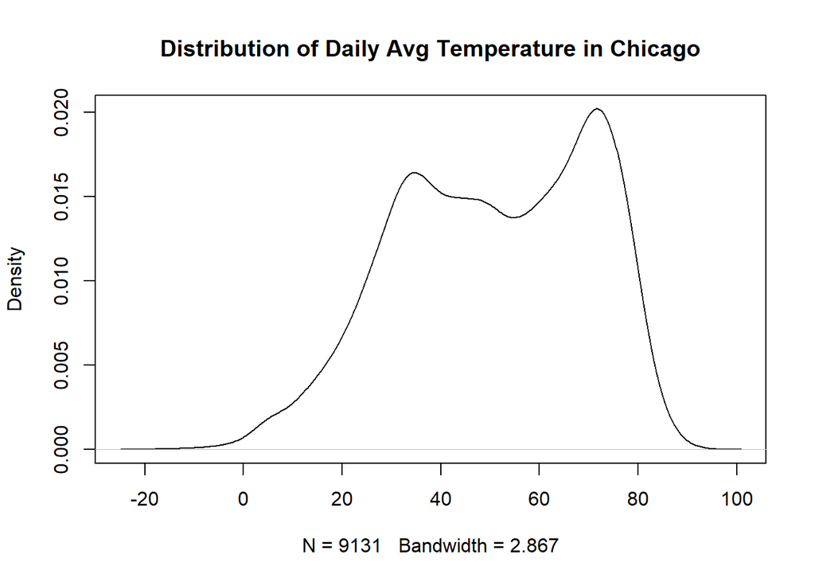

```r
# plot density
plot(density(tsTrain$AvgTemp),
     main="Distribution of Daily Avg Temperature in Chicago")
```

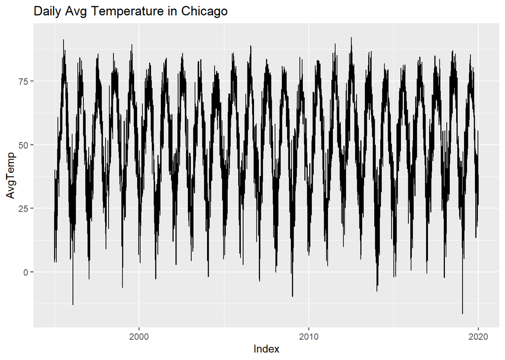

```r
# plot time series
autoplot(tsTrain$AvgTemp, main="Daily Avg Temperature in Chicago")
```

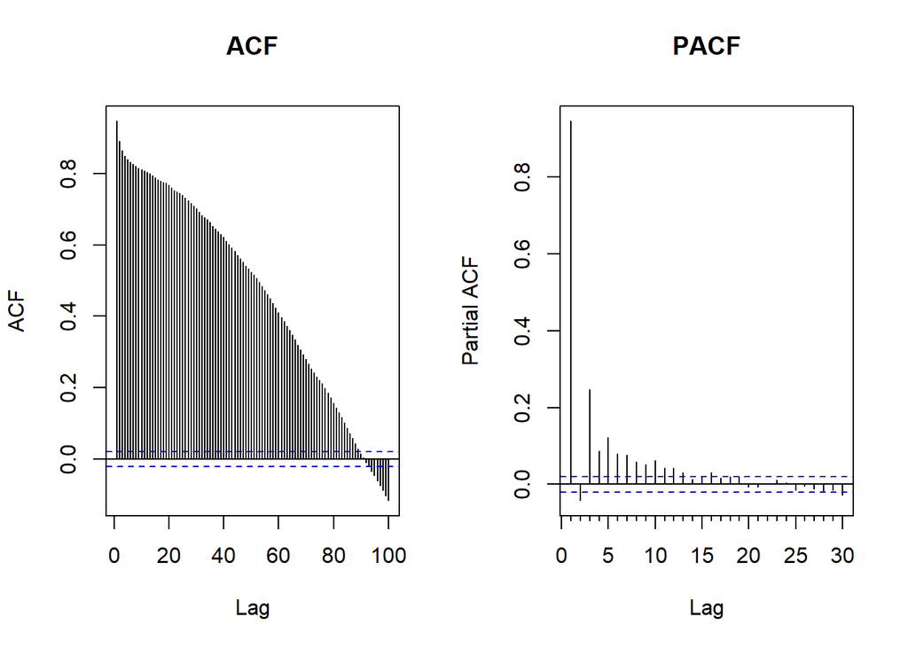

```r
layout(matrix(c(1,2),1,2,byrow = TRUE))
# acf
forecast::Acf(tsTrain$AvgTemp, main="ACF", lag.max = 100)
# pacf
forecast::Pacf(tsTrain$AvgTemp, main="PACF", lag.max = 30)
```

The ACF has long memory.

```r
adf.test(tsTrain)
```

```
##
##  Augmented Dickey-Fuller Test
##
## data:  tsTrain
## Dickey-Fuller = -5.4632, Lag order = 20, p-value = 0.01
## alternative hypothesis: stationary
```

```r
kpss.test(tsTrain)
```

```
##
##  KPSS Test for Level Stationarity
##
## data:  tsTrain
## KPSS Level = 0.064834, Truncation lag parameter = 12, p-value = 0.1
```

The ADF and KPSS tests indicate that the daily average temperature in Chicago is stationary.

ADF >> reject null that time series is not stationary KPSS >> p-value > 0.05 ~ cannot reject null that TS is stationary

```r
# Periodogram
p.d <- periodogram(tsTrain,main="Periodogram of Daily Time Series")
```

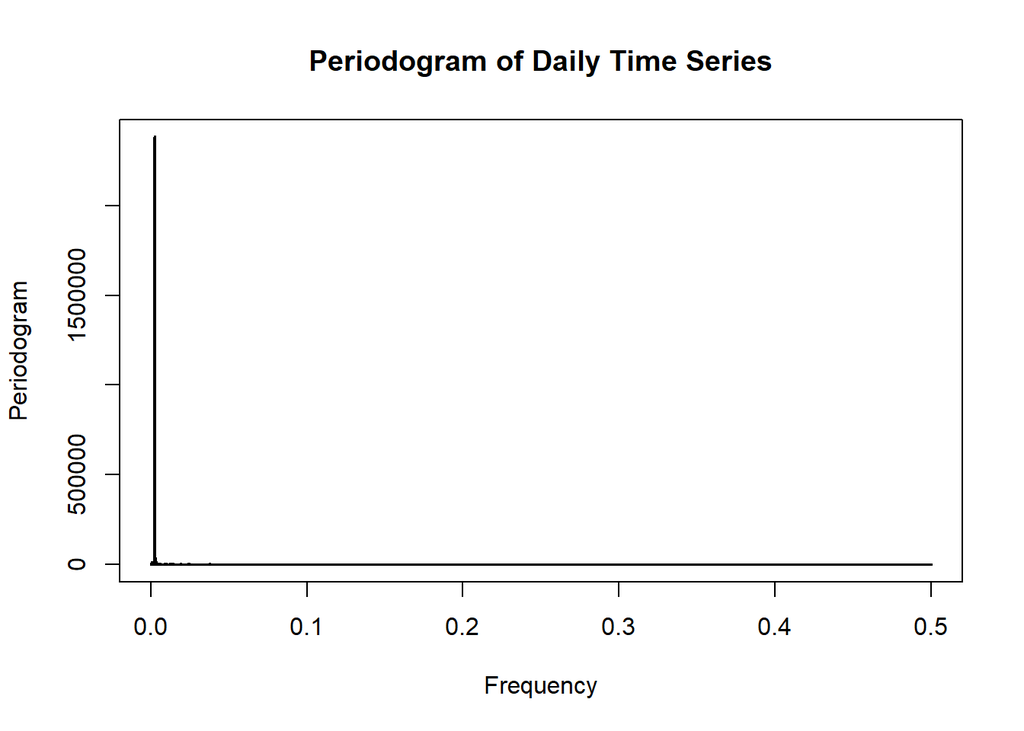

```r
(maxFreq.d <- p.d$freq[which.max(p.d$spec)])
```

```
## [1] 0.002712674
```

```r
(seasonality.d <- 1/maxFreq.d)
```

```
## [1] 368.64
```

Check the second order of the time series.

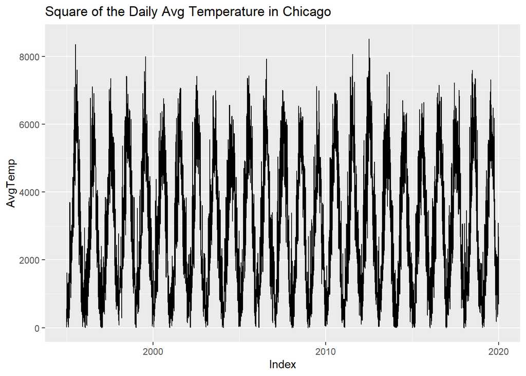

```r
# plot time series
autoplot(tsTrain$AvgTemp^2,
        main="Square of the Daily Avg Temperature in Chicago")
```

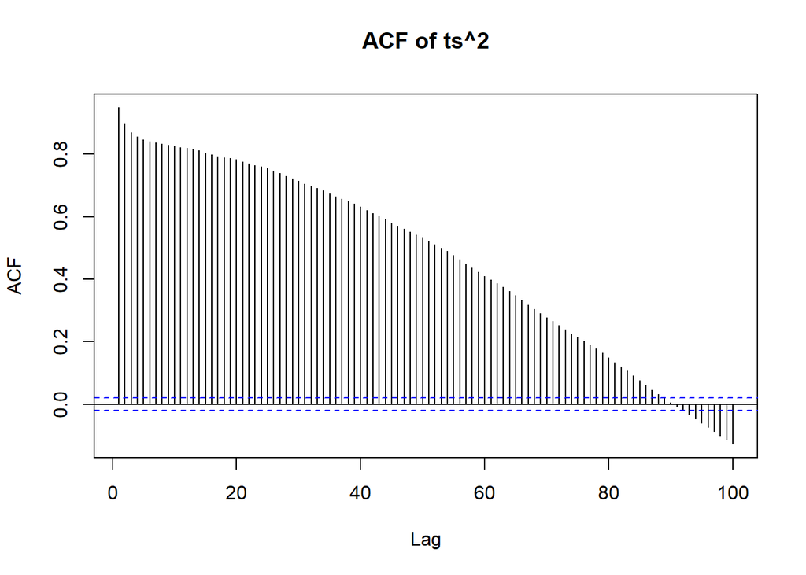

```r
# acf
forecast::Acf(tsTrain$AvgTemp^2, main="ACF of ts^2", lag.max = 100)
```

KPSS Test on the Second Order (test for heteroskedasticity)

```r
kpss.test(tsTrain^2, null = "Level")
```

```
##
##  KPSS Test for Level Stationarity
##
## data:  tsTrain^2
## KPSS Level = 0.079395, Truncation lag parameter = 12, p-value = 0.1
```

```r
kpss.test(tsTrain^2, null = "Trend")
```

```
##
##  KPSS Test for Trend Stationarity
##
## data:  tsTrain^2
## KPSS Trend = 0.03493, Truncation lag parameter = 12, p-value = 0.1
```

We fail to reject the null hypothesis of the KPSS test and conclude that the time series does not exhibit heteroskedasticity.

### Exploration of the Weekly Avg Temp in Chicago

```r
summary(tsWTrain)
```

```
##      Index               AvgTemp
##  Min.   :1995-01-01   Min.   : 2.46
##  1st Qu.:2001-04-01   1st Qu.:34.81
##  Median :2007-07-01   Median :51.44
##  Mean   :2007-07-01   Mean   :50.77
##  3rd Qu.:2013-09-29   3rd Qu.:68.40
##  Max.   :2019-12-29   Max.   :87.13
```

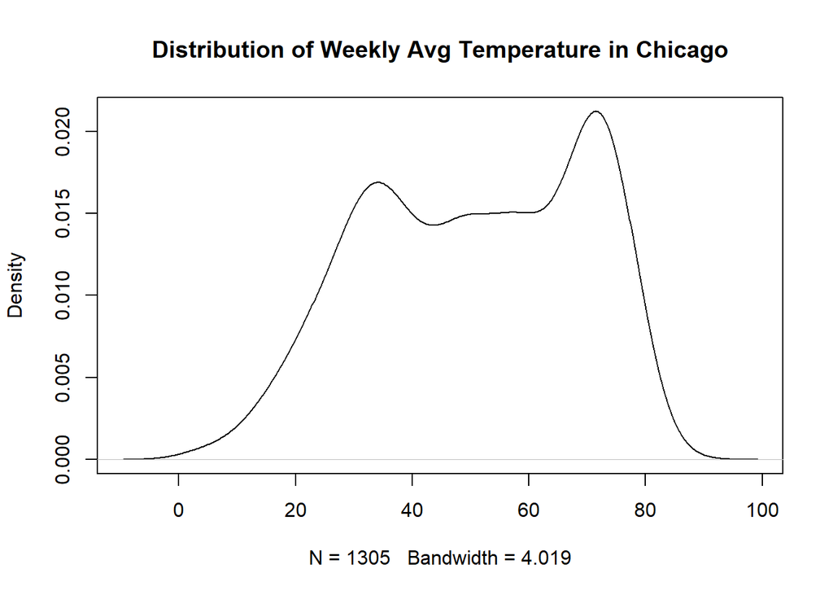

```r
# plot density
plot(density(tsWTrain$AvgTemp),
     main="Distribution of Weekly Avg Temperature in Chicago")
```

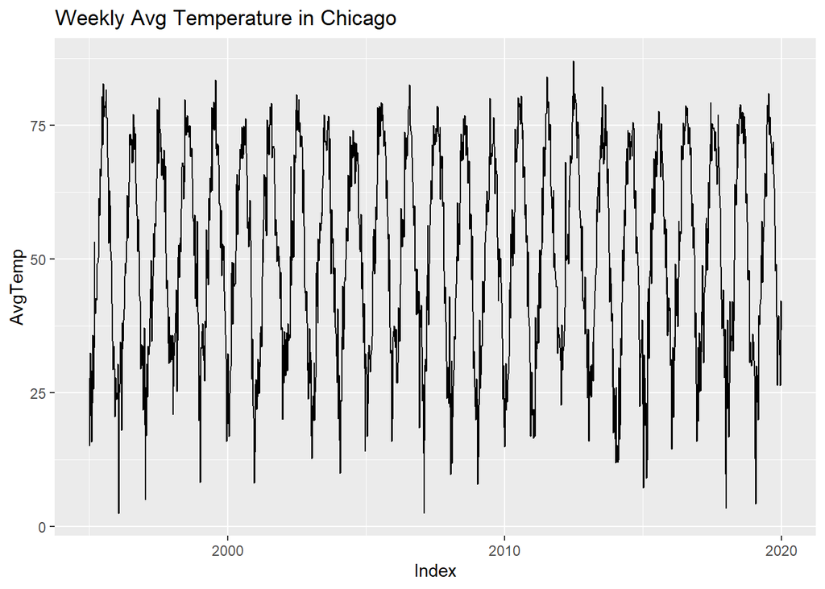

```r
# plot time series
autoplot(tsWTrain$AvgTemp, main="Weekly Avg Temperature in Chicago")
```

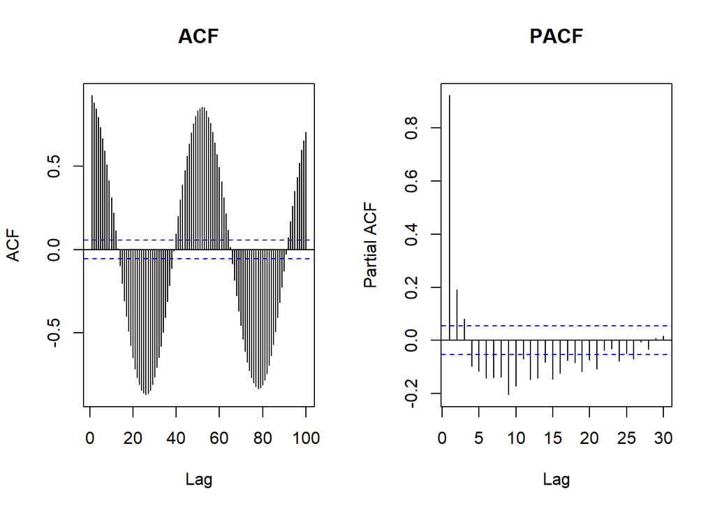

```r
layout(matrix(c(1,2),1,2,byrow = TRUE))
# acf
forecast::Acf(tsWTrain$AvgTemp, main="ACF", lag.max = 100)
# pacf
forecast::Pacf(tsWTrain$AvgTemp, main="PACF", lag.max = 30)
```

The ACF shows a repeating pattern.

```r
adf.test(tsWTrain)
```

```
##
##  Augmented Dickey-Fuller Test
##
## data:  tsWTrain
## Dickey-Fuller = -12.863, Lag order = 10, p-value = 0.01
## alternative hypothesis: stationary
```

```r
kpss.test(tsWTrain)
```

```
##
##  KPSS Test for Level Stationarity
##
## data:  tsWTrain
## KPSS Level = 0.016699, Truncation lag parameter = 7, p-value = 0.1
```

The ADF and KPSS tests indicate that the weekly average temperature in Chicago is stationary.

ADF >> reject null that time series is not stationary KPSS >> p-value > 0.05 ~ cannot reject null that TS is stationary

```r
# Periodogram
p.w <- periodogram(tsWTrain,main="Periodogram of Weekly Time Series")
```

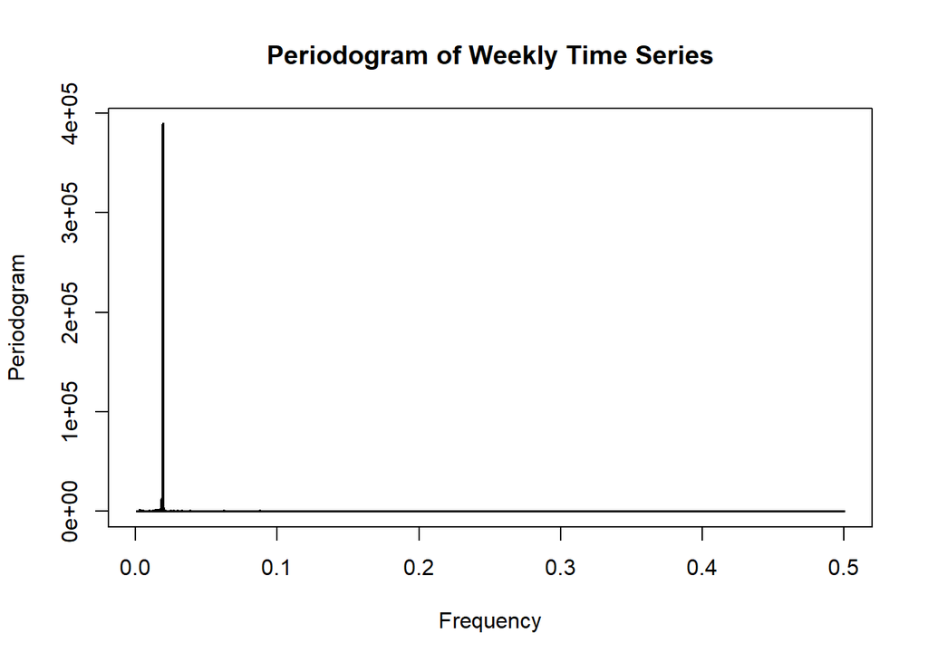

```r
(maxFreq.w <- p.w$freq[which.max(p.w$spec)])
```

```
## [1] 0.01925926
```

```r
(seasonality.w <- 1/maxFreq.w)
```

```
## [1] 51.92308
```

Check the second order of the time series.

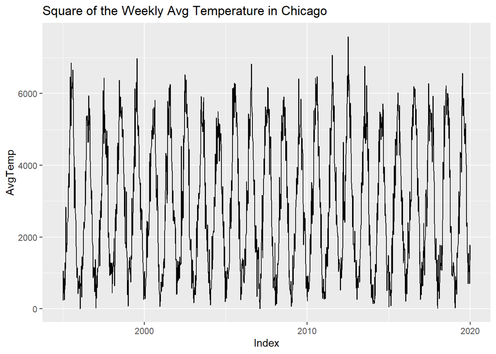

```r
# plot time series
autoplot(tsWTrain$AvgTemp^2,
        main="Square of the Weekly Avg Temperature in Chicago")
```

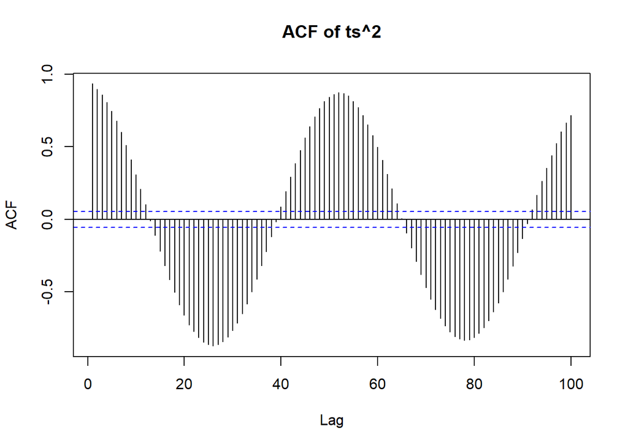

```r
# acf
forecast::Acf(tsWTrain$AvgTemp^2, main="ACF of ts^2", lag.max = 100)
```

ACF of the square of the time series shows a repeating pattern.

KPSS Test on the Second Order (test for heteroskedasticity)

```r
kpss.test(tsWTrain^2, null = "Level")
```

```
##
##  KPSS Test for Level Stationarity
##
## data:  tsWTrain^2
## KPSS Level = 0.020147, Truncation lag parameter = 7, p-value = 0.1
```

```r
kpss.test(tsWTrain^2, null = "Trend")
```

```
##
##  KPSS Test for Trend Stationarity
##
## data:  tsWTrain^2
## KPSS Trend = 0.0092338, Truncation lag parameter = 7, p-value = 0.1
```

We fail to reject the null hypothesis of the KPSS test and conclude that the time series does not exhibit heteroskedasticity.

### Exploration of the Monthly Avg Temp in Chicago

```r
summary(tsMTrain)
```

```
##      Index         AvgTemp
##  Min.   :1995   Min.   :15.89
##  1st Qu.:2001   1st Qu.:34.38
##  Median :2007   Median :52.30
##  Mean   :2007   Mean   :50.66
##  3rd Qu.:2014   3rd Qu.:68.07
##  Max.   :2020   Max.   :81.17
```

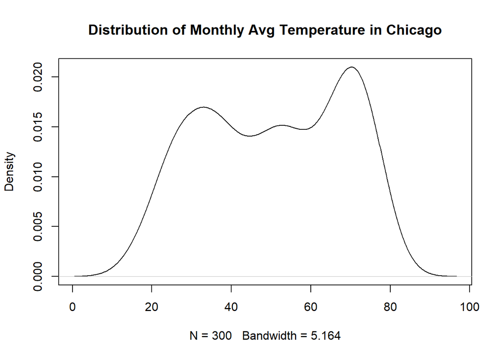

```r
# plot density
plot(density(tsMTrain$AvgTemp),
     main="Distribution of Monthly Avg Temperature in Chicago")
```

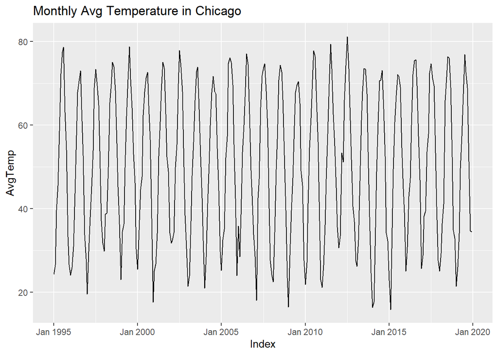

```r
# plot time series
autoplot(tsMTrain$AvgTemp, main="Monthly Avg Temperature in Chicago")
```

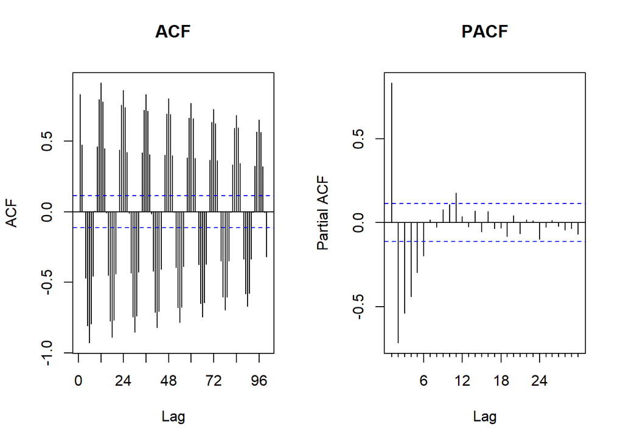

```r
layout(matrix(c(1,2),1,2,byrow = TRUE))
# acf
forecast::Acf(tsMTrain$AvgTemp, main="ACF", lag.max = 100)
# pacf
forecast::Pacf(tsMTrain$AvgTemp, main="PACF", lag.max = 30)
```

The ACF shows a repeating pattern.

```r
adf.test(tsMTrain)
```

```
##
##  Augmented Dickey-Fuller Test
##
## data:  tsMTrain
## Dickey-Fuller = -10.925, Lag order = 6, p-value = 0.01
## alternative hypothesis: stationary
```

```r
kpss.test(tsMTrain)
```

```
##
##  KPSS Test for Level Stationarity
##
## data:  tsMTrain
## KPSS Level = 0.011834, Truncation lag parameter = 5, p-value = 0.1
```

ADF >> reject null that time series is not stationary KPSS >> p-value > 0.05 ~ cannot reject null that TS is stationary

```r
# Periodogram
p.m <- periodogram(tsMTrain,main="Periodogram of Monthly Time Series")
```

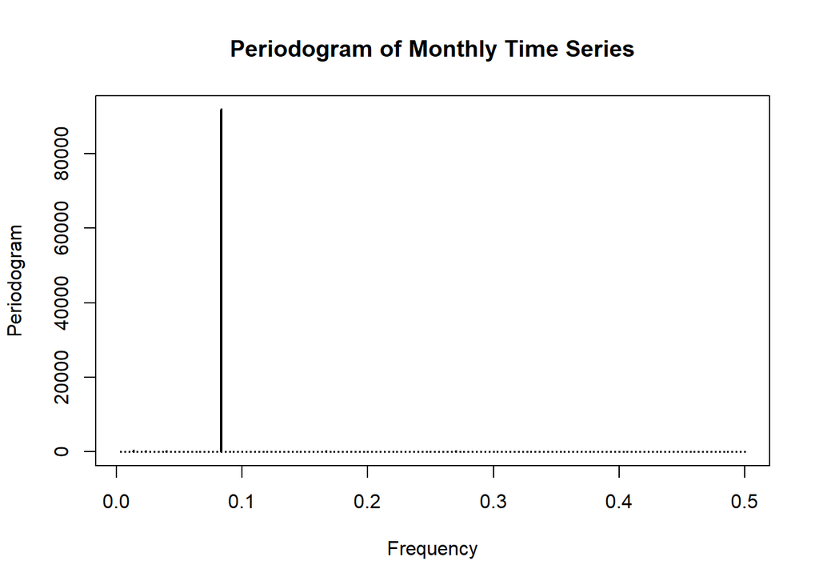

```r
(maxFreq.m <- p.m$freq[which.max(p.m$spec)])
```

```
## [1] 0.08333333
```

```r
(seasonality.m <- 1/maxFreq.m)
```

```
## [1] 12
```

Check the second order of the time series.

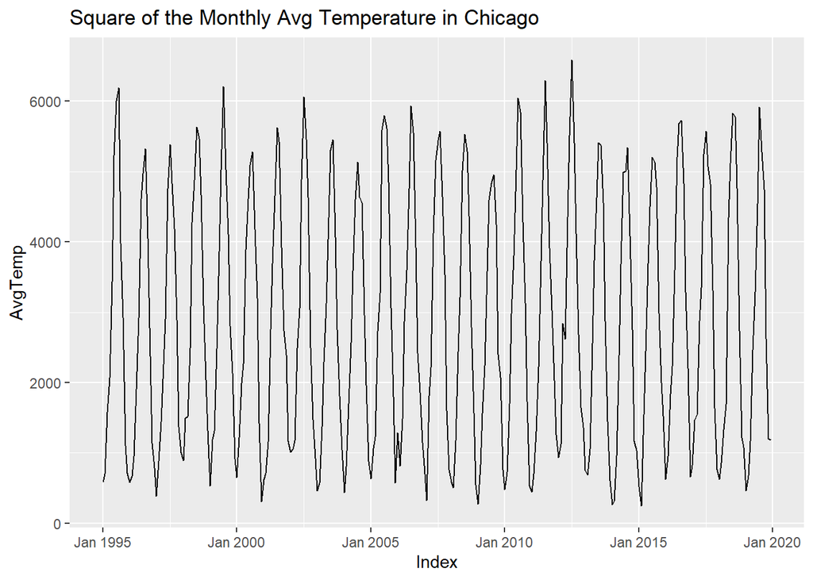

```r
# plot time series
autoplot(tsMTrain$AvgTemp^2,
        main="Square of the Monthly Avg Temperature in Chicago")
```

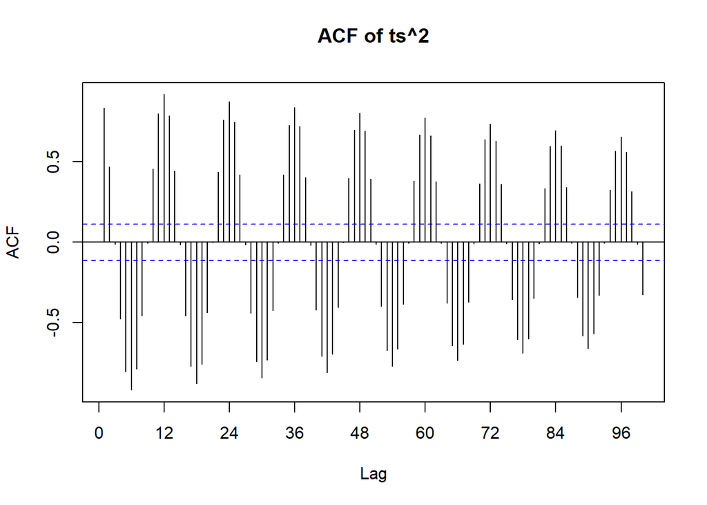

```r
# acf
forecast::Acf(tsMTrain$AvgTemp^2, main="ACF of ts^2", lag.max = 100)
```

KPSS Test on the Second Order (test for heteroskedasticity)

```r
kpss.test(tsMTrain^2, null = "Level")
```

```
##
##  KPSS Test for Level Stationarity
##
## data:  tsMTrain^2
## KPSS Level = 0.014494, Truncation lag parameter = 5, p-value = 0.1
```

```r
kpss.test(tsMTrain^2, null = "Trend")
```

```
##
##  KPSS Test for Trend Stationarity
##
## data:  tsMTrain^2
## KPSS Trend = 0.0065834, Truncation lag parameter = 5, p-value = 0.1
```

We fail to reject the null hypothesis of the KPSS test and conclude that the time series does not exhibit heteroskedasticity.